# Part I - Ford GoBike System Data Exploration

## Multivariate Exploration

#### Question: How does the average trip duration vary across the days of week and user types?

This Facet plot will help to identify patterns in trip duration based on the day of week and user type, showing whether customers or subscribers have longer rides on certain days.

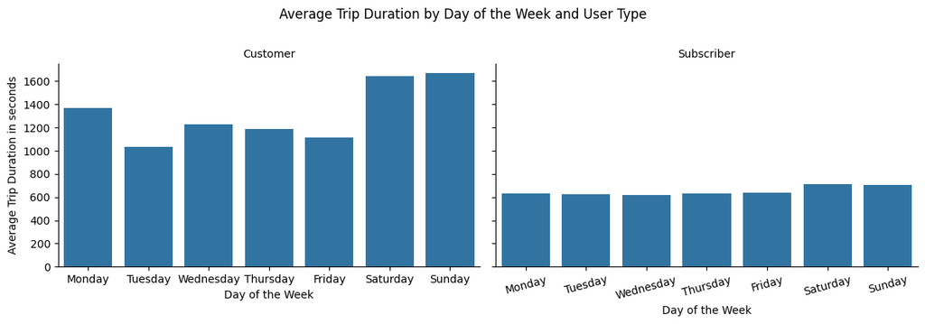

```python
    #  extract day of the week
    df['day_of_week'] =df['start_time'].dt.day_name()

    # group data by day_of_week, user_type then Calculate average trip duration
    avg_duration = df.groupby(['day_of_week', 'user_type'])['duration_sec'].mean().reset_index()

    days = ['Monday', 'Tuesday', 'Wednesday','Thursday', 'Friday','Saturday','Sunday']

    g = sns.FacetGrid(avg_duration, col="user_type", height=4, aspect=1.5)
    g.map(sns.barplot, "day_of_week", "duration_sec", order=days)
    g.set_axis_labels("Day of the Week", "Average Trip Duration in seconds")
    g.set_titles(col_template="{col_name}")
    plt.xticks(rotation= 15)
    plt.subplots_adjust(top= 0.8)
    g.fig.suptitle('Average Trip Duration by Day of the Week and User Type')
    plt.show()
```

#### Question: How does age of user correlate with the distance traveled, and does this relationship differ by user type?

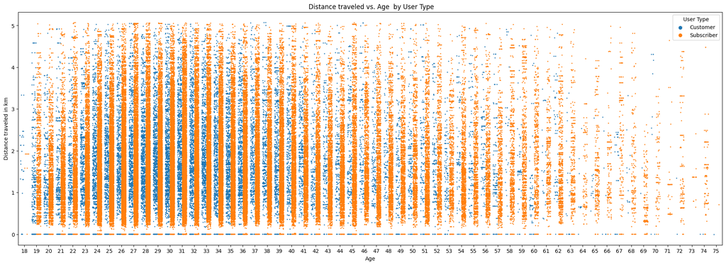

```python
    plt.figure(figsize=[24, 8])
    sns.stripplot(data=df.query('age <= 75 and distance_km <= distance_km.quantile(0.99)'),y='distance_km', x='age',hue='user_type',size=2,jitter=0.35, dodge=True)
    plt.ylabel('Distance traveled in km')
    plt.xlabel('Age')
    plt.title(' Distance traveled vs. Age  by User Type')
    plt.legend(title='User Type')
    plt.show()
```